# Estimating present population based on Mobile Network Operator data - a simulation study

Giulia and Marco

```r
library(tidyverse)
library(data.table)
library(sf)
library(lubridate)
library(raster)
library(Matrix)

set.seed(762)
```

# Loading in / cleaning census data from Germany

For this version census data from Germany was retrieved. This data entails population count categories on the 1km*1km tile level. Additional meta information such as age proportions etc. are included and will be utilized in subsequent versions. Furthermore, for computational reasons, this version will only focus on a subset of the tiles located in the state of Bavaria. However, the code is written in a modularized way in order to easily scale, once a high computing machine is available.  
In the following chunk this census data is cleaned and random (realistic) values for the population count variable are generated instead of the categorical scale. These random values are based on the relevant category the respective tile entails. Furthermore, this population value is used throughout this version as the number of mobile phones in a specific tile. This means, this variable represents the u vector in the working paper. In subsequent versions this original population value will be adjusted based on auxiliary variables to get a more realistic count of people with mobile phones in the tile area.

```r
census.raw <- read_csv2("Data/Census data Germany/Zensus 1km.csv")
```

```
## Using ',' as decimal and '.' as grouping mark. Use read_delim() for more control.
```

```r
census.de.1km <- census.raw %>%
  dplyr::select(x = x_mp_1km, y = y_mp_1km, tile.id = Gitter_ID_1km, pop = Einwohner) %>%
  mutate(internal.id = row_number()) %>%
  mutate(pop = case_when(pop == 1 ~ sample(1:250, n(), replace = T),
                         pop == 2 ~ sample(250:500, n(), replace = T),
                         pop == 3 ~ sample(500:2000, n(), replace = T),
                         pop == 4 ~ sample(2000:4000, n(), replace = T),
                         pop == 5 ~ sample(4000:8000, n(), replace = T),
                         pop == 6 ~ sample(8000:12000, n(), replace = T),
                         pop == "-1" ~ as.integer(1)))

# Filtering only tiles within specified bounding box, creating tile polygons and transforming the object to an sf object with a specific coordinate reference system (projection)
census.de.1km.tile <- census.de.1km %>%
  filter(between(y, 2800000, 2850000),
         between(x, 4500000, 4600000)) %>%
  rasterFromXYZ(crs = st_crs(3035)$proj4string) %>%
  rasterToPolygons() %>%
  st_as_sf() %>%
  st_transform(crs = 3035)
```

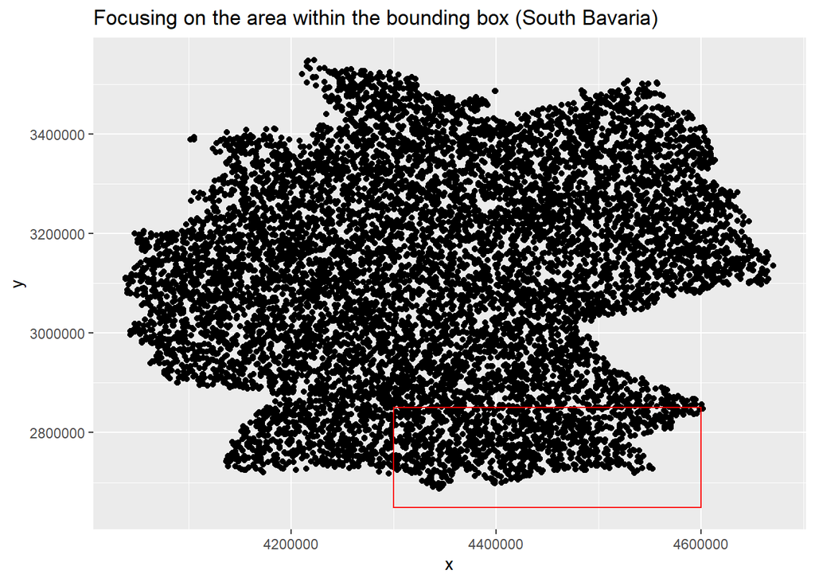

```r
# Bounding box of focus area
focus.bb <- data.frame(maxlat = 4600000, minlat = 4300000,
                       maxlong = 2850000, minlong = 2650000)

# Focusing on the area within the bounding box (south bavaria)
census.de.1km %>%
  sample_n(10000) %>%
  ggplot() +
  geom_point(aes(x = x, y = y)) +
  geom_rect(data = focus.bb, aes(ymin = minlong, ymax = maxlong,
                                 xmin = minlat, xmax = maxlat),
            color = "red", fill = "transparent") +
  ggtitle("Focusing on the area within the bounding box (South Bavaria)")
```

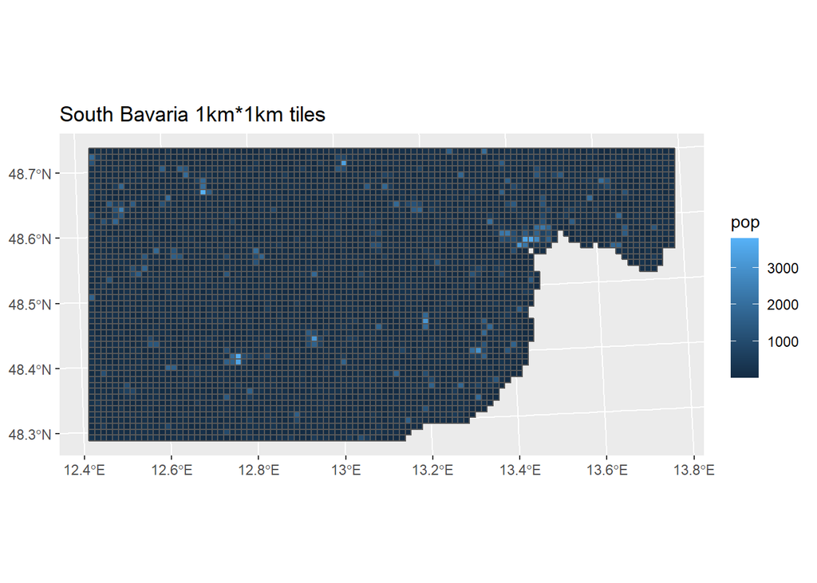

```r
# Focus area
census.de.1km.tile %>%
  ggplot() +
  geom_sf(aes(fill = pop)) +
  ggtitle("South Bavaria 1km*1km tiles")
```

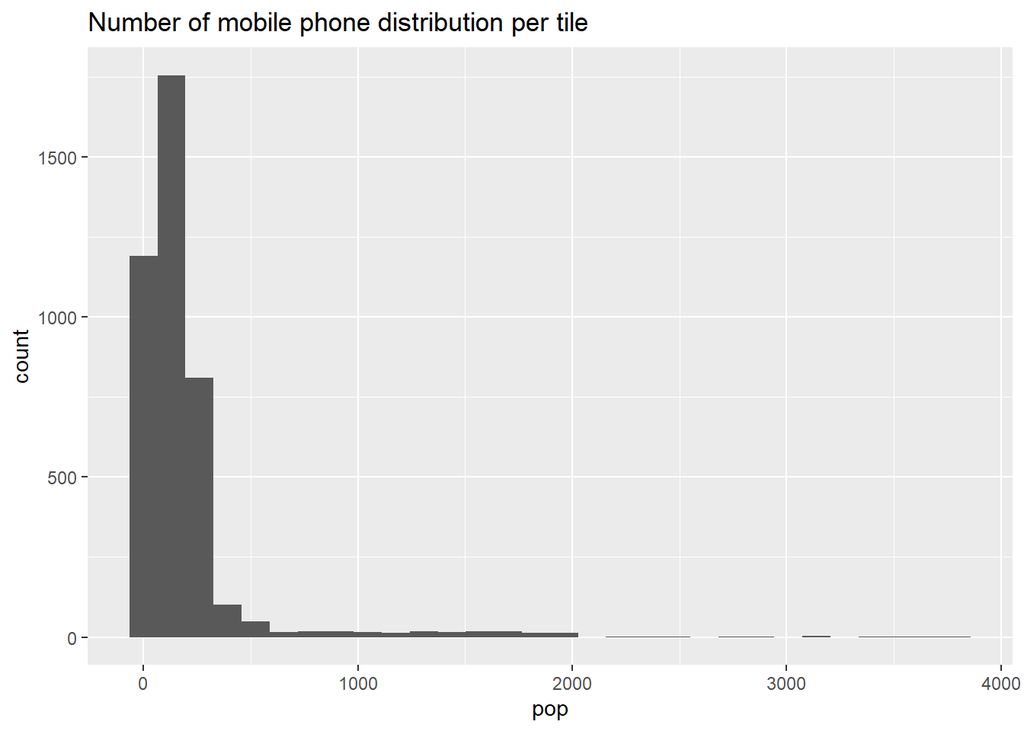

```r
# Histograms of population distribution
census.de.1km.tile %>%
  ggplot() +
  geom_histogram(aes(pop)) +
  ggtitle("Number of mobile phone distribution per tile")
```

# Generation of the Radio Network

```r
# define illumnation intensity sij for each tile


## Generation of radio network ###
# Real data concerning cell towers in Germany
cell.tower.hilzen.raw <- read.csv("https://raw.githubusercontent.com/dahilzen/Mobilfunk-Scrape/master/Alle_Funkmasten_BRD.csv")
cell.tower.position <- cell.tower.hilzen.raw %>%
  rename(tower.id = fID) %>%
  filter(type == "Mobilfunk") %>%
  st_as_sf(coords = c("lon", "lat"), crs = st_crs(4326)$proj4string) %>%
  st_transform(crs = 3035) %>%
  st_crop(xmin = 4500000, xmax = 4600000,
          ymin = 2800000, ymax = 2850000) # filtering based on boundary box
```

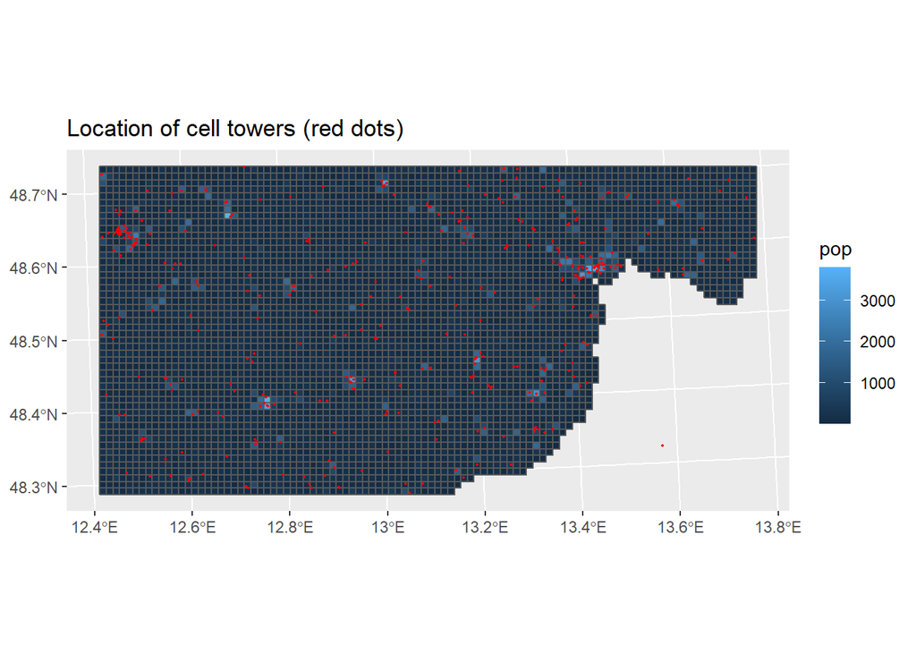

```r
# mapping cell towers on census map
census.de.1km.tile %>%
  ggplot() +
  geom_sf(aes(fill = pop)) +
  geom_sf(data = cell.tower.position, col = "red", size = 0.4) +
  ggtitle("Location of cell towers (red dots)")
```

```r
# one can see that cell towers cluster, where it is more urban
```

This data only entails the cell tower position, however, there is no indication concerning the number of antennas per cell tower, nor antenna specific characteristics such as direction, tilt, coverage area or signal strength. In order to derive a more realistic scenario some of these parameters will be implemented in subsequent versions. Signal strength will be simulated in a later stage of this document. Currently, it is assumed that there is only one antenna per cell tower and this antenna has a coverage area based on Voronoi tesselation (Alternative 1, non-overlapping coverage areas) or on differing sized buffers (Alternative 2, possibly overlapping coverage areas). However, again, the code is very easy adjustable to integrate more variables. This part ends with a map, presenting the tiles from South Bavaria and the respective coverage areas as polygons. This means one can see which tiles are captured within which coverage area (Device-to-cell association).

### Alternative 1: Voronoi tesselation –> non overlapping polygons

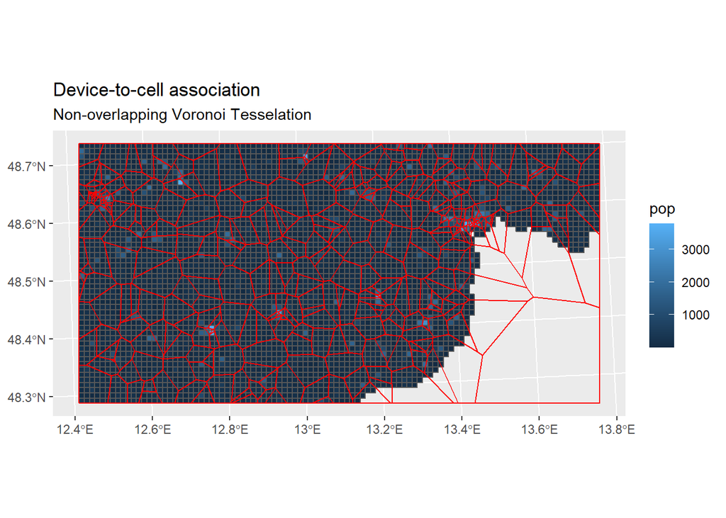

```r
# Defining the coverage area
# TO DO: create multiple cells per tower
radio.cells <- cell.tower.position %>%
  # slice(rep(1:n(), each = 3)) %>%
  mutate(universal.id = paste0("RC.", row_number())) %>%
  mutate(cell.centroid = st_centroid(geometry))
  # group_by(tower.id) %>%
  # mutate(tower.cell.id = paste0("T.RC.", row_number()))


# Option with Voronoi tesselation
# Coverage area is dataframe with radio cells in the rows and their geometries constituting their respective coverage area
# random.cell.vec <- sample(nrow(radio.cells))
# TO DO: create overlapping coverage areas
# TO DO: Implement signaling strength, currently uniform
coverage.areas <- radio.cells %>%
  st_union() %>% # unite them
  st_voronoi() %>% # and perform the voronoi tessellation
  st_collection_extract(type = "POLYGON") %>% # select the polygons
  st_sf(crs = 3035) %>%
  st_crop(xmin = 4500000, xmax = 4600000,
          ymin = 2800000, ymax = 2850000) %>%
  st_join(radio.cells) %>% # & re-connect the data items
  st_set_agr("aggregate") %>%  # clean up
  mutate(signal.str = 1) # uniform

# Overlaying the coverage areas with the census data (Device to cell association)
coverage.areas %>%
  ggplot() +
  geom_sf(data = census.de.1km.tile, aes(fill = pop)) +
  geom_sf(col = 'red', fill = NA) +
  ggtitle("Device-to-cell association", "Non-overlapping Voronoi Tesselation")
```

### Alternative 2: Random Buffering –> Overlapping polygons

Here the coverage area depends on a 5 category scale which currently is assigned to each radio cell randomly. Each category entails a different polygon size representing the coverage area. This coverage area currently always has the location of its radio cell as its centroid. Due to differing sizes, coverage areas can overlap, meaning that tiles can be “illuminated” by multiple radio cells.

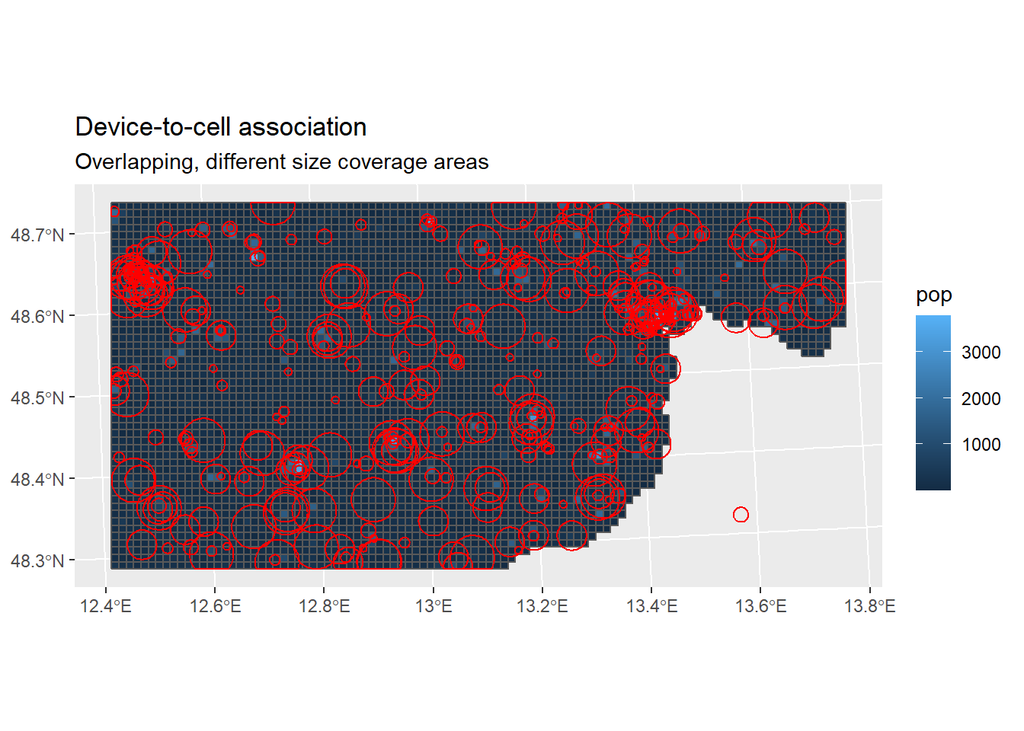

```r
# random vector, which radio cell should get which size of coverage area
# TO DO: instead of random categories there should be a model underneath this, such as differences between urban and rural areas, etc..
random.vec <- sample(c(1:5), length(radio.cells$tower.id), replace = T)
buffer.cat <- c("1" = 500, "2" = 700, "3" = 1000, "4" = 2000, "5" = 3000)

coverage.areas.over <- radio.cells %>%
  mutate(random.vec = random.vec) %>%
  split(.$random.vec) %>%
  map2_df(., buffer.cat, ~st_buffer(.x, .y)) %>%
  st_sf(., crs = 3035) %>%
  st_crop(xmin = 4500000, xmax = 4600000,
          ymin = 2800000, ymax = 2850000) %>%
  st_set_agr("aggregate") %>%  # clean up
  mutate(cell.centroid = st_centroid(geometry))
coverage.areas.over %>%
  ggplot() +
  geom_sf(data = census.de.1km.tile, aes(fill = pop)) +
  geom_sf(col = 'red', fill = NA) +
  ggtitle("Device-to-cell association", "Overlapping, different size coverage areas")
```

# Device-to-cell association

```r
dev.to.cell <- census.de.1km.tile %>%
  mutate(tile.centroid = st_centroid(geometry)) %>%
  st_join(coverage.areas.over, left = F) %>%
  mutate(dist.sij = st_distance(cell.centroid, tile.centroid, by_element = T)) %>%
  mutate(signal.sij = 1 / (dist.sij * random.vec)) %>% # dependent threshold value
  group_by(internal.id) %>%
  mutate(weight.pij = as.numeric(signal.sij / sum(signal.sij, na.rm = T)))

# sparse matrix of device to cell
P.mat <- dev.to.cell %>%
  dplyr::select(internal.id, universal.id, weight.pij) %>%
  st_drop_geometry() %>%
  pivot_wider(id_cols = universal.id, names_from = internal.id,
              values_from = weight.pij) %>%
  as.matrix() %>%
  Matrix(sparse = T)
```

```r
# u-vector
U.vec <- census.de.1km.tile %>%
  dplyr::select(internal.id, pop)

# C-vector (total count of mobile phones of a tile stochastically assigned to a radio cell based on P --> here: weight.pij)
C.vec <- dev.to.cell %>%
  dplyr::select(internal.id, universal.id, pop, weight.pij) %>%
  st_drop_geometry() %>%
  split(.$internal.id) %>%
  map(~sample(x = .$universal.id, mean(.$pop),
                              replace = T, prob = .$weight.pij)) %>%
  map(as_tibble, .id = "internal.id") %>%
  map(~group_by(., value)) %>%
  map(~summarise(., pop.count.rand = n(), .groups = "drop"))
# TO DO: Implement example of the stochastic process
```

## Current questions:

- **Is there a difference between an antenna and a radio cell?**
- **What is the difference between the module “Generation of radio network” and the module “Network modelling” in the working paper**
- **What is meant with seeds**

## Major TO DOs:

**Implement a “scenario table” which acts as a vignette for every scenario and which parameters are specified**